# Activity monitoring data analysis

2022-09-12

## Loading and preprocessing the data

#### 1. Code for reading in the dataset and/or processing the data

```r
library(readr)

if(!file.exists("./data")){dir.create("./data")}
fileUrl <- "https://d396qusza40orc.cloudfront.net/repdata%2Fdata%2Factivity.zip"
download.file(fileUrl, destfile = "./data/repdata_data_activity.zip", mode = "wb")
unzip("./data/repdata_data_activity.zip")

activity <- read_csv("activity.csv")
dim(activity)
```

```
## [1] 17568     3
```

```r
head(activity)
```

```
## # A tibble: 6 × 3
##   steps date       interval
##   <dbl> <date>        <dbl>
## 1    NA 2012-10-01        0
## 2    NA 2012-10-01        5
## 3    NA 2012-10-01       10
## 4    NA 2012-10-01       15
## 5    NA 2012-10-01       20
## 6    NA 2012-10-01       25
```

```r
summary(activity)
```

```
##      steps             date               interval
##  Min.   :  0.00   Min.   :2012-10-01   Min.   :   0.0
##  1st Qu.:  0.00   1st Qu.:2012-10-16   1st Qu.: 588.8
##  Median :  0.00   Median :2012-10-31   Median :1177.5
##  Mean   : 37.38   Mean   :2012-10-31   Mean   :1177.5
##  3rd Qu.: 12.00   3rd Qu.:2012-11-15   3rd Qu.:1766.2
##  Max.   :806.00   Max.   :2012-11-30   Max.   :2355.0
##  NA's   :2304
```

```r
str(activity)
```

```
## spec_tbl_df [17,568 × 3] (S3: spec_tbl_df/tbl_df/tbl/data.frame)
##  $ steps   : num [1:17568] NA NA NA NA NA NA NA NA NA NA ...
##  $ date    : Date[1:17568], format: "2012-10-01" "2012-10-01" ...
##  $ interval: num [1:17568] 0 5 10 15 20 25 30 35 40 45 ...
##  - attr(*, "spec")=
##   .. cols(
##   ..   steps = col_double(),
##   ..   date = col_date(format = ""),
##   ..   interval = col_double()
##   .. )
##  - attr(*, "problems")=<externalptr>
```

## What is mean total number of steps taken per day?

#### 1. Histogram of the total number of steps taken each day

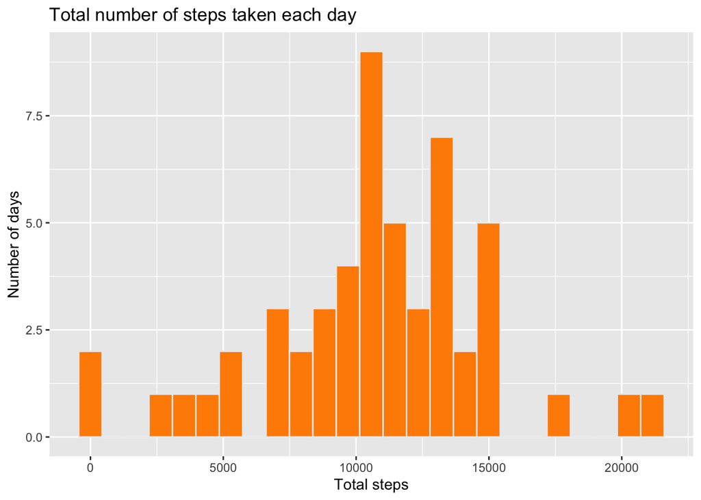

```r
library(ggplot2)
library(dplyr)
library(RColorBrewer)

activity_daily <- activity %>%
    group_by(date) %>%
    summarise(total_steps = sum(steps))

# 1. Histogram of the total number of steps taken each day
attach(activity_daily)
g1 <- ggplot(aes(total_steps), data = activity_daily)
g1 + geom_histogram(aes(total_steps), bins = 25, fill="dark orange", color="#e9ecef") +
    labs(title = "Total number of steps taken each day", x = "Total steps", y = "Number of days")
```

```r
# 2. Mean and median number of steps taken each day

stat_steps <- activity %>%
    group_by(date) %>%
    summarise(mean_steps = mean(steps), median_steps = median(steps))
```

[output not shown]

## What is the average daily activity pattern?

#### 3. Time series plot of the average number of steps taken

#### 4. The 5-minute interval that, on average, contains the maximum number of steps

```r
attach(activity)
```

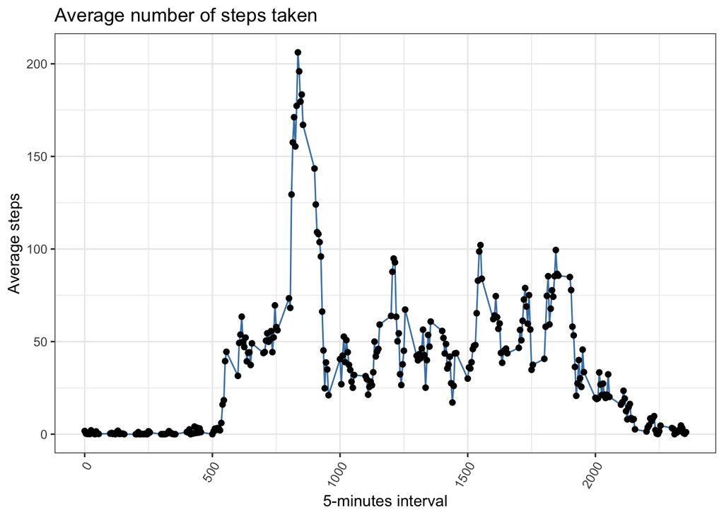

```r
activity_mnts <- activity %>%
    group_by(interval) %>%
    summarise(avg_steps = mean(steps, na.rm = TRUE))

#3. Time series plot of the average number of steps taken
attach(activity_mnts)
g <- ggplot(aes(x = interval, y = avg_steps), data = activity_mnts)
g + geom_line(color="steelblue") +
    geom_point() +
    labs(title = "Average number of steps taken", x = "5-minutes interval", y = "Average steps") +

    theme_bw() +
    theme(axis.text.x = element_text(angle = 60, hjust = 1))
```

```r
# 4. The 5-minute interval that, on average, contains the maximum number of steps
max_steps_interval <- with(activity_mnts, interval[which.max(avg_steps)])
max_steps_interval
```

```
## [1] 835
```

## Imputing missing values

#### 5. Code to describe and show a strategy for imputing missing data

#### 6. Histogram of the total number of steps taken each day after missing values are imputed

Q. What is the impact of imputing missing data on the estimates of the total daily number of steps?

A. The impact on estimation fo total daily number of steps are the distribution of the data.

```r
#Calculate and report the total number of missing values in the dataset
num_na <- activity %>%
    count(is.na(steps))
num_na
```

```
## # A tibble: 2 × 2
##   `is.na(steps)`     n
##   <lgl>          <int>
## 1 FALSE          15264
## 2 TRUE            2304
```

```r
#use the mean for that 5-minute interval to fill NA value
new_activity <- left_join(activity, activity_mnts, by = "interval")
new_activity$steps[is.na(new_activity$steps)] <- new_activity$avg_steps[is.na(new_activity$steps)]
new_activity
```

```
## # A tibble: 17,568 × 4
##     steps date       interval avg_steps
##     <dbl> <date>        <dbl>     <dbl>
##  1 1.72   2012-10-01        0    1.72
##  2 0.340  2012-10-01        5    0.340
##  3 0.132  2012-10-01       10    0.132
##  4 0.151  2012-10-01       15    0.151
##  5 0.0755 2012-10-01       20    0.0755
##  6 2.09   2012-10-01       25    2.09
##  7 0.528  2012-10-01       30    0.528
##  8 0.868  2012-10-01       35    0.868
##  9 0      2012-10-01       40    0
## 10 1.47   2012-10-01       45    1.47
## # … with 17,558 more rows
```

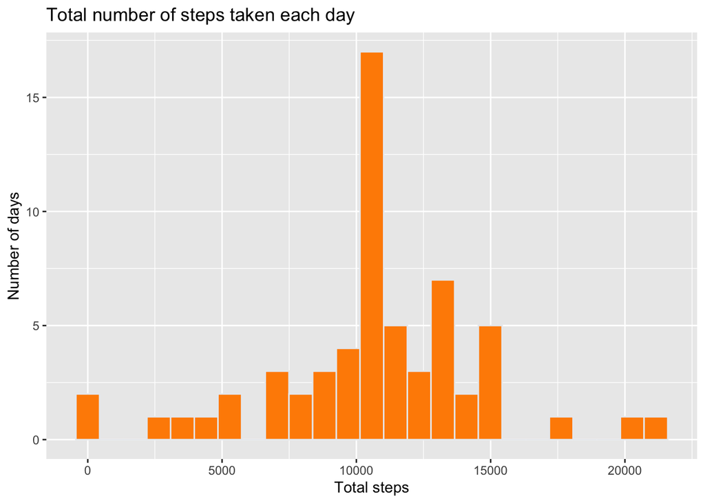

```r
#Histogram of the total number of steps taken each day after missing values are imputed

new_activity_daily <- new_activity %>%
    group_by(date) %>%
    summarise(total_steps = sum(steps))

attach(new_activity_daily)
g2 <- ggplot(aes(total_steps), data = new_activity_daily)
g2 + geom_histogram(aes(total_steps), bins = 25, fill="dark orange", color="#e9ecef") +
    labs(title = "Total number of steps taken each day", x = "Total steps", y = "Number of days")
```

```r
new_stat_steps <- new_activity %>%
    group_by(date) %>%
    summarise(mean_steps = mean(steps), median_steps = median(steps))
```

## Are there differences in activity patterns between weekdays and weekends?

#### 7. Panel plot comparing the average number of steps taken per 5-minute interval across weekdays and weekends

#### 8. All of the R code needed to reproduce the results (numbers, plots, etc.) in the report

```r
library(lubridate)
week_activity <- new_activity %>%
    mutate(weekdays = wday(new_activity$date, week_start = 1))

week_activity$weekdays <- replace(week_activity$weekdays, week_activity$weekdays > 5, "weekend")
week_activity$weekdays <- replace(week_activity$weekdays, week_activity$weekdays < 6, "weekday")

week_activity$weekdays <- as.factor(week_activity$weekdays)

week_activity <- week_activity %>%
    group_by(interval, weekdays) %>%
    summarise(avg_steps = mean(steps))
attach(week_activity)
```

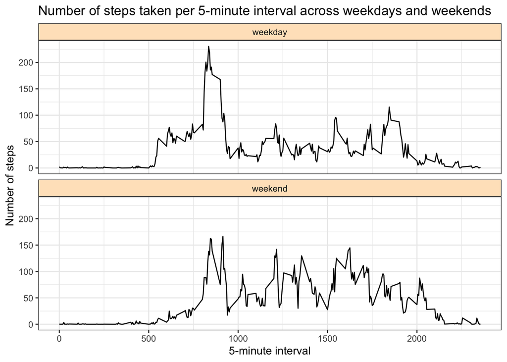

```r
ggplot(aes(interval, avg_steps), data = week_activity)  +
    geom_line() +
    facet_wrap(weekdays, nrow = 2, ncol = 1) +
    labs(title = "Number of steps taken per 5-minute interval across weekdays and weekends", x = "5-minute interval", y = "Number of steps") +
    theme_bw() +
    theme(strip.background = element_rect(fill = "bisque"))
```